# Does Bangalore have a second summer?

2026-09-10

## Question and definitions

The test is deliberately split into two meanings of “hot”:

- **Afternoon heat:** monthly mean of daily maximum temperature (`High`).
- **Whole-day warmth:** monthly mean of the midpoint of daily high and low.

The historical comparison uses complete July–October months from 1981–2025. A later month counts as a second-summer month if its value is higher than both July and August in the same year. This is a test of recurrence, not a claim that the later month is hotter than Bangalore’s true pre-monsoon summer (March–May).

## Data checks and preparation

```r
weather <- read_csv(file.path(root_dir, "docs", "data", "bangalore_daily_weather.csv"), show_col_types = FALSE) %>%
  mutate(date = ymd(DT), year = year(date), month = month(date),
         mean_temp = (High + Low) / 2)

monthly <- weather %>%
  summarise(
    days = n_distinct(date),
    mean_high = mean(High, na.rm = TRUE),
    mean_low = mean(Low, na.rm = TRUE),
    mean_temp = mean(mean_temp, na.rm = TRUE),
    rain_mm = sum(Rain, na.rm = TRUE),
    rainy_days = sum(Rain > 0.1, na.rm = TRUE),
    days_30 = sum(High >= 30, na.rm = TRUE),
    .by = c(year, month)
  ) %>%
  mutate(expected_days = days_in_month(make_date(year, month, 1))) %>%
  filter(days == expected_days)

hist <- monthly %>% filter(year >= 1981, year <= 2025, month %in% 7:10)
coverage <- hist %>% count(year) %>% summarise(years = n(), min_months = min(n), max_months = max(n))
coverage
```

```
## # A tibble: 1 × 3
##   years min_months max_months
##   <int>      <int>      <int>
## 1    45          4          4
```

The archive has 16688 daily rows from 1981-01-01 through 2026-09-09. The historical test has 180 complete month-years and 45 years with all four months present.

## What the averages say

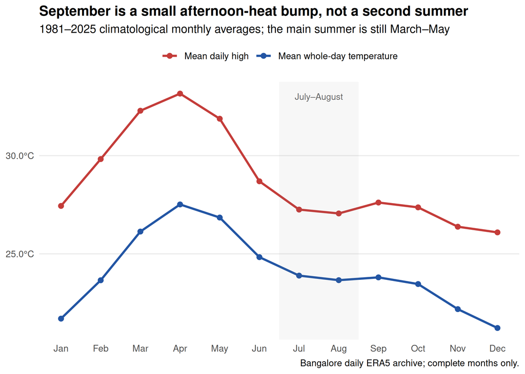

```r
clim <- monthly %>% filter(year >= 1981, year <= 2025) %>%
  group_by(month) %>% summarise(
    mean_high = mean(mean_high), mean_temp = mean(mean_temp),
    rain_mm = mean(rain_mm), .groups = "drop"
  ) %>%
  pivot_longer(c(mean_high, mean_temp), names_to = "measure", values_to = "temperature") %>%
  mutate(measure = recode(measure, mean_high = "Mean daily high", mean_temp = "Mean whole-day temperature"))

p_clim <- ggplot(clim, aes(month, temperature, colour = measure)) +
  geom_line(linewidth = 1) + geom_point(size = 2) +
  annotate("rect", xmin = 6.5, xmax = 8.5, ymin = -Inf, ymax = Inf, alpha = .06, fill = "#777777") +
  annotate("text", x = 7.5, y = max(clim$temperature) - .15, label = "July–August", colour = "#666666", size = 3) +
  scale_x_continuous(breaks = 1:12, labels = month.abb) +
  scale_y_continuous(labels = label_number(accuracy = .1, suffix = "°C")) +
  scale_colour_manual(values = c("Mean daily high" = "#C43C39", "Mean whole-day temperature" = "#2255A4")) +
  labs(title = "September is a small afternoon-heat bump, not a second summer",
       subtitle = "1981–2025 climatological monthly averages; the main summer is still March–May",
       x = NULL, y = NULL, colour = NULL, caption = "Bangalore daily ERA5 archive; complete months only.") +
  theme_minimal(base_size = 11) + theme(legend.position = "top", panel.grid.minor = element_blank(),
    panel.grid.major.x = element_blank(), plot.title = element_text(face = "bold"))
p_clim
```

```r
ggsave(file.path(chart_dir, "bangalore-second-summer-climatology.png"), p_clim, width = 11, height = 6, dpi = 160, bg = "white")
```

Historically, September’s mean daily high is 27.61°C, versus 27.25°C in July and 27.06°C in August. But whole-day temperature does not peak in September: cooler nights offset the slightly warmer afternoons.

## Does it happen in individual years?

```r
wide <- hist %>% select(year, month, mean_high, mean_temp, rain_mm, days_30) %>% pivot_wider(names_from = month, values_from = c(mean_high, mean_temp, rain_mm, days_30))
results <- tibble(
  measure = c("Mean daily high", "Mean whole-day temperature", "Days with high >= 30°C"),
  september_years = c(sum(wide$mean_high_9 > pmax(wide$mean_high_7, wide$mean_high_8)),
                      sum(wide$mean_temp_9 > pmax(wide$mean_temp_7, wide$mean_temp_8)),
                      sum(wide$days_30_9 > pmax(wide$days_30_7, wide$days_30_8))),
  october_years = c(sum(wide$mean_high_10 > pmax(wide$mean_high_7, wide$mean_high_8)),
                    sum(wide$mean_temp_10 > pmax(wide$mean_temp_7, wide$mean_temp_8)),
                    sum(wide$days_30_10 > pmax(wide$days_30_7, wide$days_30_8)))
) %>% mutate(total_years = nrow(wide), september_share = september_years / total_years, october_share = october_years / total_years)
results
```

```
## # A tibble: 3 × 6
##   measure              september_years october_years total_years september_share
##   <chr>                          <int>         <int>       <int>           <dbl>
## 1 Mean daily high                   25            21          45           0.556
## 2 Mean whole-day temp…              14             4          45           0.311
## 3 Days with high >= 3…               9             9          45           0.2
## # ℹ 1 more variable: october_share <dbl>
```

```r
rain_effect <- hist %>% filter(month %in% 9:10) %>% group_by(month) %>% summarise(
  rain_high_correlation = cor(rain_mm, mean_high),
  dry_half_high = mean(mean_high[rain_mm <= median(rain_mm)]),
  wet_half_high = mean(mean_high[rain_mm > median(rain_mm)]), .groups = "drop")
rain_effect
```

```
## # A tibble: 2 × 4
##   month rain_high_correlation dry_half_high wet_half_high
##   <dbl>                 <dbl>         <dbl>         <dbl>
## 1     9                -0.353          27.8          27.4
## 2    10                -0.417          27.6          27.1
```

## The year-by-year pattern

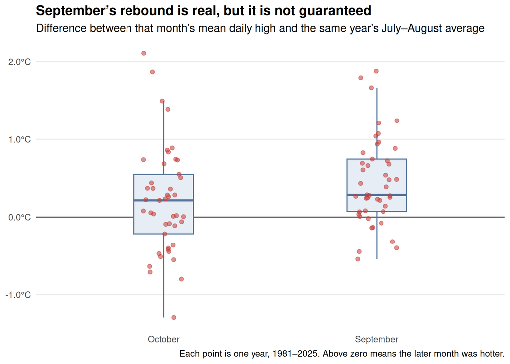

```r
differences <- hist %>%
  select(year, month, mean_high, mean_temp) %>%
  pivot_wider(names_from = month, values_from = c(mean_high, mean_temp)) %>%
  transmute(year,
            September = mean_high_9 - (mean_high_7 + mean_high_8) / 2,
            October = mean_high_10 - (mean_high_7 + mean_high_8) / 2) %>%
  pivot_longer(-year, names_to = "month", values_to = "difference")

p_diff <- ggplot(differences, aes(month, difference)) +
  geom_hline(yintercept = 0, colour = "#555555", linewidth = .5) +
  geom_boxplot(width = .28, outlier.shape = NA, fill = "#E7EDF5", colour = "#55739A") +
  geom_jitter(width = .10, height = 0, alpha = .55, size = 1.6, colour = "#C43C39") +
  scale_y_continuous(labels = label_number(accuracy = .1, suffix = "°C")) +
  labs(title = "September’s rebound is real, but it is not guaranteed",
       subtitle = "Difference between that month’s mean daily high and the same year’s July–August average",
       x = NULL, y = NULL, caption = "Each point is one year, 1981–2025. Above zero means the later month was hotter.") +
  theme_minimal(base_size = 11) + theme(panel.grid.minor = element_blank(),
    panel.grid.major.x = element_blank(), plot.title = element_text(face = "bold"))
p_diff
```

```r
ggsave(file.path(chart_dir, "bangalore-second-summer-year-differences.png"), p_diff, width = 8, height = 5.5, dpi = 160, bg = "white")
```

September beats both July and August in afternoon heat in 25 of 45 years (56%). October does so in 21 years (47%). For whole-day warmth, the corresponding shares are only 31% and 9%.

Rain matters, but it is not the whole explanation. The September correlation between monthly rain and mean daily high is -0.35; October’s is -0.42. The dry-half versus wet-half difference is larger in October than September, but year-to-year variability remains substantial.

## 2026 so far — a genuine hot September, but incomplete

```r
current <- weather %>% filter(year == analysis_year, month == 9, day(date) <= 9) %>% summarise(
  days = n(), mean_high = mean(High), mean_temp = mean(mean_temp), rain_mm = sum(Rain), days_30 = sum(High >= 30))
prior_same_window <- weather %>% filter(year <= 2025, month == 9, day(date) <= 9) %>% summarise(.by = year, mean_high = mean(High), mean_temp = mean(mean_temp), rain_mm = sum(Rain), days_30 = sum(High >= 30))
current
```

```
## # A tibble: 1 × 5
##    days mean_high mean_temp rain_mm days_30
##   <int>     <dbl>     <dbl>   <dbl>   <int>
## 1     9      31.2      26.4    1.24       6
```

```r
prior_same_window %>% summarise(years = n(), high_rank = 1 + sum(mean_high > current$mean_high), temp_rank = 1 + sum(mean_temp > current$mean_temp), rain_rank_driest = 1 + sum(rain_mm < current$rain_mm))
```

```
## # A tibble: 1 × 4
##   years high_rank temp_rank rain_rank_driest
##   <int>     <dbl>     <dbl>            <dbl>
## 1    45         1         1                2
```

The first nine days of September 2026 average 31.19°C for the daily high and 26.42°C across the day, with only 1.2 mm of rain. Against the same 1–9 September window in 1981–2025, that is rank 1 for both heat measures. It is therefore a real hot spell, but it is not evidence by itself that the climatological season has a second summer; the month is incomplete and the comparison is weather variability around a modest September shoulder.

## Verdict

Insightful: yes

Bangalore does have a recurring **September afternoon-heat rebound**, but not a second summer in the stronger, whole-day sense. September’s average daily high is about 0.4°C above July–August, and it beats both months in a little over half of historical years; October is less consistent. Cooler post-monsoon nights mean September’s whole-day temperature is roughly flat with July–August, while October is cooler. Rain suppresses the later-month afternoon high in wetter years, helping explain why the average hides hot, dry exceptions such as September 2026. The chart is saved as `docs/assets/analysis/bangalore-second-summer-climatology.png`.